# Week 1 Case Study: Deep Learning Fundamentals

**Student Name:** Siddhartha Mukherjee

**Course:** Applied Research Topics in Deep Learning

**Date:** 2026-04-07

```python
# Imports
import numpy as np
import pandas as pd
import matplotlib.pyplot as plt
import seaborn as sns
import warnings
warnings.filterwarnings('ignore')

from sklearn.model_selection import train_test_split
from sklearn.preprocessing import StandardScaler
from sklearn.metrics import accuracy_score, classification_report, confusion_matrix

import tensorflow as tf
from tensorflow.keras.models import Sequential
from tensorflow.keras.layers import Dense

plt.rcParams['figure.figsize'] = (8, 5)
sns.set_style('whitegrid')

print(f"NumPy: {np.__version__}")
print(f"TensorFlow: {tf.__version__}")
```

```
NumPy: 2.0.2
TensorFlow: 2.19.0
```

## Dataset Attribute Information:

1. age (age)
2. sex (sex)
3. chest pain type (4 values) (cp)
4. resting blood pressure (trestbps)
5. serum cholestoral in mg/dl (chol)
6. fasting blood sugar > 120 mg/dl (fbs)
7. resting electrocardiographic results (values 0,1,2) (restecg)
8. maximum heart rate achieved (thalach)
9. exercise induced angina (exang)
10. oldpeak = ST depression induced by exercise relative to rest (oldpeak)
11. the slope of the peak exercise ST segment (slope)
12. number of major vessels (0-3) colored by flourosopy (ca)
13. thal: 0 = normal; 1 = fixed defect; 2 = reversable defect (thal)

```python
!curl -L -o heart-disease-dataset.zip \
https://www.kaggle.com/api/v1/datasets/download/johnsmith88/heart-disease-dataset
```

```
  % Total    % Received % Xferd  Average Speed   Time    Time     Time  Current
                                 Dload  Upload   Total   Spent    Left  Speed
  0     0    0     0    0     0      0      0 --:--:-- --:--:-- --:--:--     0
100  6325  100  6325    0     0  16190      0 --:--:-- --:--:-- --:--:-- 16190
```

```python
!unzip -o -q heart-disease-dataset.zip -d ./
```

```python
df = pd.read_csv('heart.csv')
print(f"Dataset shape: {df.shape}")
df.head()
```

```
Dataset shape: (1025, 14)
```

|  | age | sex | cp | trestbps | chol | fbs | restecg | thalach | exang | oldpeak | slope | ca | thal | target |
| --- | --- | --- | --- | --- | --- | --- | --- | --- | --- | --- | --- | --- | --- | --- |
| 0 | 52 | 1 | 0 | 125 | 212 | 0 | 1 | 168 | 0 | 1.0 | 2 | 2 | 3 | 0 |
| 1 | 53 | 1 | 0 | 140 | 203 | 1 | 0 | 155 | 1 | 3.1 | 0 | 0 | 3 | 0 |
| 2 | 70 | 1 | 0 | 145 | 174 | 0 | 1 | 125 | 1 | 2.6 | 0 | 0 | 3 | 0 |
| 3 | 61 | 1 | 0 | 148 | 203 | 0 | 1 | 161 | 0 | 0.0 | 2 | 1 | 3 | 0 |
| 4 | 62 | 0 | 0 | 138 | 294 | 1 | 1 | 106 | 0 | 1.9 | 1 | 3 | 2 | 0 |

## Part 1: Data Preparation & Analysis

### 1.1 Basic Data Exploration

```python
# Basic info about the dataset
print("=== Dataset Info ===")
print(f"Shape: {df.shape}")
print(f"\nColumn Types:\n{df.dtypes}")
print(f"\n=== Missing Values ===\n{df.isnull().sum()}")
print(f"\n=== Duplicates: {df.duplicated().sum()} ===")
```

```
=== Dataset Info ===
Shape: (1025, 14)

Column Types:
age           int64
sex           int64
cp            int64
trestbps      int64
chol          int64
fbs           int64
restecg       int64
thalach       int64
exang         int64
oldpeak     float64
slope         int64
ca            int64
thal          int64
target        int64
dtype: object

=== Missing Values ===
age         0
sex         0
cp          0
trestbps    0
chol        0
fbs         0
restecg     0
thalach     0
exang       0
oldpeak     0
slope       0
ca          0
thal        0
target      0
dtype: int64

=== Duplicates: 723 ===
```

```python
# Drop duplicates
print(f"Before: {df.shape[0]} rows")
df = df.drop_duplicates()
print(f"After: {df.shape[0]} rows")
```

```
Before: 1025 rows
After: 302 rows
```

```python
print("=== Target Distribution ===")
print(df['target'].value_counts())
print(f"\nBalance: {df['target'].mean():.2%} positive (heart disease)")
```

```
=== Target Distribution ===
target
1    164
0    138
Name: count, dtype: int64

Balance: 54.30% positive (heart disease)
```

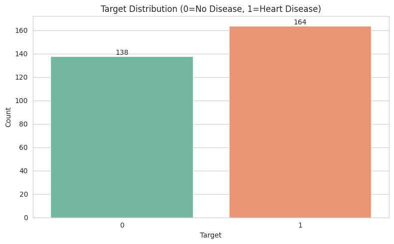

```python
fig, ax = plt.subplots()
sns.countplot(x='target', data=df, palette='Set2', ax=ax)
ax.set_title('Target Distribution (0=No Disease, 1=Heart Disease)')
ax.set_xlabel('Target')
ax.set_ylabel('Count')
for p in ax.patches:
    ax.annotate(f'{int(p.get_height())}', (p.get_x() + p.get_width()/2., p.get_height()),
                ha='center', va='bottom')
plt.tight_layout()
plt.show()
```

### 1.2 Feature Visualizations

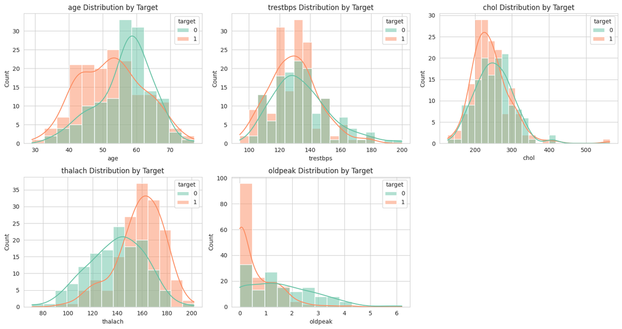

```python
continuous = ['age', 'trestbps', 'chol', 'thalach', 'oldpeak']

fig, axes = plt.subplots(2, 3, figsize=(15, 8))
axes = axes.flatten()

for i, col in enumerate(continuous):
    sns.histplot(data=df, x=col, hue='target', kde=True, ax=axes[i], palette='Set2')
    axes[i].set_title(f'{col} Distribution by Target')

axes[-1].set_visible(False)  # hide the 6th empty subplot
plt.tight_layout()
plt.show()
```

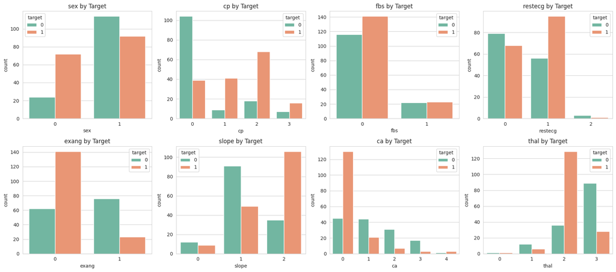

```python
categorical = ['sex', 'cp', 'fbs', 'restecg', 'exang', 'slope', 'ca', 'thal']

fig, axes = plt.subplots(2, 4, figsize=(18, 8))
axes = axes.flatten()

for i, col in enumerate(categorical):
    sns.countplot(data=df, x=col, hue='target', palette='Set2', ax=axes[i])
    axes[i].set_title(f'{col} by Target')

plt.tight_layout()
plt.show()
```

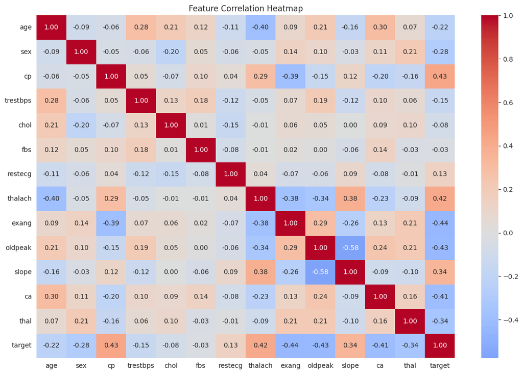

```python
fig, ax = plt.subplots(figsize=(12, 8))
sns.heatmap(df.corr(), annot=True, fmt='.2f', cmap='coolwarm', center=0, ax=ax)
ax.set_title('Feature Correlation Heatmap')
plt.tight_layout()
plt.show()
```

### 1.3 Key EDA Observations

**Categorical Features:**

- **cp** (chest pain type): Strong differentiator — type 2 is heavily associated with heart disease
- **thal**: Values of 2 (reversible defect) strongly indicate heart disease; value 3 (normal) indicates no disease
- **ca** (number of major vessels): ca=0 strongly associated with heart disease
- **exang** (exercise-induced angina): exang=0 (no angina) is more common in heart disease patients
- **sex**: More males in the dataset — potential source of bias (we'll discuss in Part 5)

**Dataset Balance:** ~54% positive / ~46% negative — reasonably balanced, so accuracy is a fair evaluation metric.

### 1.4 Outlier Detection

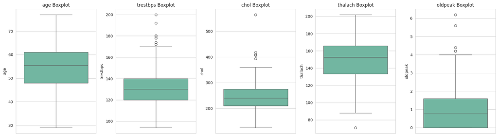

```python
fig, axes = plt.subplots(1, 5, figsize=(18, 5))

for i, col in enumerate(continuous):
    sns.boxplot(data=df, y=col, ax=axes[i], palette='Set2')
    axes[i].set_title(f'{col} Boxplot')

plt.tight_layout()
plt.show()
```

```python
print("=== Outlier Count (IQR Method) ===\n")
for col in continuous:
    Q1 = df[col].quantile(0.25)
    Q3 = df[col].quantile(0.75)
    IQR = Q3 - Q1
    lower = Q1 - 1.5 * IQR
    upper = Q3 + 1.5 * IQR
    outliers = df[(df[col] < lower) | (df[col] > upper)]
    print(f"{col}: {len(outliers)} outliers (range: {lower:.1f} - {upper:.1f})")
```

```
=== Outlier Count (IQR Method) ===

age: 0 outliers (range: 28.5 - 80.5)
trestbps: 9 outliers (range: 90.0 - 170.0)
chol: 5 outliers (range: 115.4 - 370.4)
thalach: 1 outliers (range: 84.1 - 215.1)
oldpeak: 5 outliers (range: -2.4 - 4.0)
```

### Outlier Handling Decision

Outliers detected (IQR method): trestbps (9), chol (5), oldpeak (5), thalach (1), age (0).

**Decision: Keep outliers.** With only 302 samples, removing outliers would lose too much data. These values may be medically valid (e.g., high blood pressure patients). StandardScaler will handle the scale differences, and neural networks are generally robust to moderate outliers.

### 1.5 Train/Validation/Test Split & Feature Scaling

```python
# Separate features and target
X = df.drop('target', axis=1)
y = df['target']

# First split: 70% train, 30% temp
X_train, X_temp, y_train, y_temp = train_test_split(X, y, test_size=0.30, random_state=42, stratify=y)

# Second split: split temp into 15% val, 15% test
X_val, X_test, y_val, y_test = train_test_split(X_temp, y_temp, test_size=0.50, random_state=42, stratify=y_temp)

print(f"Train set:      {X_train.shape[0]} samples ({X_train.shape[0]/len(df):.0%})")
print(f"Validation set: {X_val.shape[0]} samples ({X_val.shape[0]/len(df):.0%})")
print(f"Test set:       {X_test.shape[0]} samples ({X_test.shape[0]/len(df):.0%})")
```

```
Train set:      211 samples (70%)
Validation set: 45 samples (15%)
Test set:       46 samples (15%)
```

```python
# Scale features using StandardScaler (fit on train only!)
scaler = StandardScaler()
X_train_scaled = scaler.fit_transform(X_train)
X_val_scaled = scaler.transform(X_val)
X_test_scaled = scaler.transform(X_test)

print(f"Train mean (should be ~0): {X_train_scaled.mean():.4f}")
print(f"Train std  (should be ~1): {X_train_scaled.std():.4f}")
```

```
Train mean (should be ~0): -0.0000
Train std  (should be ~1): 1.0000
```

## Part 2: Neural Network from Scratch (NumPy)

### 2.1 Helper Functions

```python
# Sigmoid activation function
def sigmoid(z):
    return 1 / (1 + np.exp(-np.clip(z, -500, 500)))
    # np.exp(1000)  # gives overflow error, hence we clip z to prevent it


# Derivative of sigmoid (needed for backpropagation)
def sigmoid_derivative(a):
    return a * (1 - a)

# Binary cross-entropy loss
def binary_cross_entropy(y_true, y_pred):
    epsilon = 1e-8  # avoid log(0)
    y_pred = np.clip(y_pred, epsilon, 1 - epsilon)
    return -np.mean(y_true * np.log(y_pred) + (1 - y_true) * np.log(1 - y_pred))
```

### 2.2 Neural Network Class

```python
class NeuralNetworkFromScratch:
    def __init__(self, input_size, hidden_size, output_size, learning_rate=0.01):
        # Initialize weights randomly (small values) and biases as zeros
        np.random.seed(42)
        self.W1 = np.random.randn(input_size, hidden_size) * 0.01
        self.b1 = np.zeros((1, hidden_size))
        self.W2 = np.random.randn(hidden_size, output_size) * 0.01
        self.b2 = np.zeros((1, output_size))
        self.lr = learning_rate
        self.losses = []

    def forward(self, X):
        """Forward propagation: Input → Hidden → Output"""
        self.Z1 = X @ self.W1 + self.b1           # weighted sum (hidden)
        self.A1 = sigmoid(self.Z1)                  # activation (hidden)
        self.Z2 = self.A1 @ self.W2 + self.b2      # weighted sum (output)
        self.A2 = sigmoid(self.Z2)                  # prediction (output)
        return self.A2

    def backward(self, X, y):
        """Backpropagation: compute gradients"""
        m = X.shape[0]  # number of samples
        y = y.reshape(-1, 1)

        # Output layer gradients
        dZ2 = self.A2 - y                                    # error at output
        dW2 = (self.A1.T @ dZ2) / m                          # gradient for W2
        db2 = np.sum(dZ2, axis=0, keepdims=True) / m         # gradient for b2

        # Hidden layer gradients
        dZ1 = (dZ2 @ self.W2.T) * sigmoid_derivative(self.A1)  # error at hidden
        dW1 = (X.T @ dZ1) / m                                   # gradient for W1
        db1 = np.sum(dZ1, axis=0, keepdims=True) / m            # gradient for b1

        # Update weights and biases (gradient descent)
        self.W2 -= self.lr * dW2
        self.b2 -= self.lr * db2
        self.W1 -= self.lr * dW1
        self.b1 -= self.lr * db1

    def train(self, X, y, epochs=200, X_val=None, y_val=None):
        """Training loop"""
        self.val_losses = []
        for epoch in range(epochs):
            # Forward pass
            predictions = self.forward(X)

            # Compute loss
            loss = binary_cross_entropy(y.reshape(-1, 1), predictions)
            self.losses.append(loss)

            # Validation loss
            if X_val is not None:
                val_pred = self.forward(X_val)
                val_loss = binary_cross_entropy(y_val.reshape(-1, 1), val_pred)
                self.val_losses.append(val_loss)
                self.forward(X)  # re-run forward on train to restore activations

            # Backward pass
            self.backward(X, y)

            # Print progress every 50 epochs
            if (epoch + 1) % 50 == 0:
                val_str = f", Val Loss: {val_loss:.4f}" if X_val is not None else ""
                print(f"Epoch {epoch+1}/{epochs} - Loss: {loss:.4f}{val_str}")

    def predict(self, X):
        """Make predictions (0 or 1)"""
        probabilities = self.forward(X)
        return (probabilities >= 0.5).astype(int).flatten()
```

### 2.3 Training the Neural Network

```python
# Convert to numpy arrays
y_train_np = y_train.values.astype(float)
y_val_np = y_val.values.astype(float)
y_test_np = y_test.values.astype(float)

# Create and train the network: 13 inputs → 8 hidden → 1 output
nn = NeuralNetworkFromScratch(input_size=13, hidden_size=8, output_size=1, learning_rate=0.01)
nn.train(X_train_scaled, y_train_np, epochs=200, X_val=X_val_scaled, y_val=y_val_np)
```

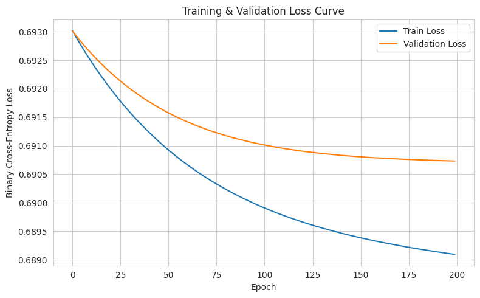

```python
fig, ax = plt.subplots()
ax.plot(nn.losses, label='Train Loss')
ax.plot(nn.val_losses, label='Validation Loss')
ax.set_xlabel('Epoch')
ax.set_ylabel('Binary Cross-Entropy Loss')
ax.set_title('Training & Validation Loss Curve')
ax.legend()
plt.tight_layout()
plt.show()
```

```
=== Scratch NN Performance ===

Train Accuracy:      0.5450
Validation Accuracy: 0.5333
Test Accuracy:       0.5435

=== Test Set Classification Report ===
               precision    recall  f1-score   support

   No Disease       0.00      0.00      0.00        21
Heart Disease       0.54      1.00      0.70        25

     accuracy                           0.54        46
    macro avg       0.27      0.50      0.35        46
 weighted avg       0.30      0.54      0.38        46

=== Confusion Matrix (Test Set) ===
```

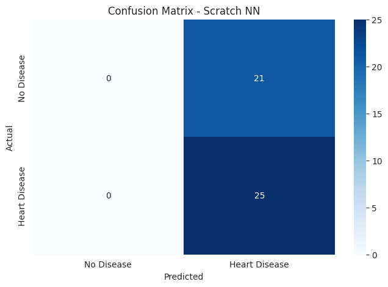

```python
# Predictions
y_train_pred = nn.predict(X_train_scaled)
y_val_pred = nn.predict(X_val_scaled)
y_test_pred = nn.predict(X_test_scaled)

print("=== Scratch NN Performance ===\n")
print(f"Train Accuracy:      {accuracy_score(y_train, y_train_pred):.4f}")
print(f"Validation Accuracy: {accuracy_score(y_val, y_val_pred):.4f}")
print(f"Test Accuracy:       {accuracy_score(y_test, y_test_pred):.4f}")

print("\n=== Test Set Classification Report ===")
print(classification_report(y_test, y_test_pred, target_names=['No Disease', 'Heart Disease']))

print("=== Confusion Matrix (Test Set) ===")
cm = confusion_matrix(y_test, y_test_pred)
sns.heatmap(cm, annot=True, fmt='d', cmap='Blues',
            xticklabels=['No Disease', 'Heart Disease'],
            yticklabels=['No Disease', 'Heart Disease'])
plt.xlabel('Predicted')
plt.ylabel('Actual')
plt.title('Confusion Matrix - Scratch NN')
plt.show()
```

### 2.4 Improved Training (Higher Learning Rate & More Epochs)

The first model did not learn properly — loss was stuck near 0.693 which means it was just guessing randomly. The learning rate of 0.01 was too small and 200 epochs was not enough. So I increased the learning rate to 0.1 and trained for 1000 epochs.

```python
# Retrain with higher learning rate and more epochs
nn = NeuralNetworkFromScratch(input_size=13, hidden_size=8, output_size=1, learning_rate=0.1)
nn.train(X_train_scaled, y_train_np, epochs=1000, X_val=X_val_scaled, y_val=y_val_np)
```

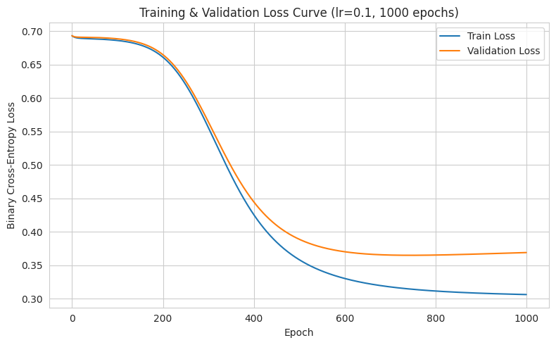

```python
fig, ax = plt.subplots()
ax.plot(nn.losses, label='Train Loss')
ax.plot(nn.val_losses, label='Validation Loss')
ax.set_xlabel('Epoch')
ax.set_ylabel('Binary Cross-Entropy Loss')
ax.set_title('Training & Validation Loss Curve (lr=0.1, 1000 epochs)')
ax.legend()
plt.tight_layout()
plt.show()
```

```
=== Improved Scratch NN Performance ===

Train Accuracy:      0.8863
Validation Accuracy: 0.8000
Test Accuracy:       0.7609

=== Test Set Classification Report ===
               precision    recall  f1-score   support

   No Disease       0.69      0.86      0.77        21
Heart Disease       0.85      0.68      0.76        25

     accuracy                           0.76        46
    macro avg       0.77      0.77      0.76        46
 weighted avg       0.78      0.76      0.76        46

=== Confusion Matrix (Test Set) ===
```

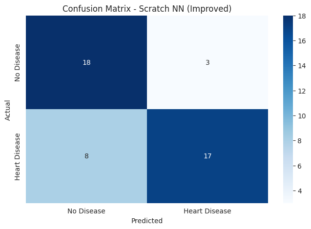

```python
y_train_pred = nn.predict(X_train_scaled)
y_val_pred = nn.predict(X_val_scaled)
y_test_pred = nn.predict(X_test_scaled)

print("=== Improved Scratch NN Performance ===\n")
print(f"Train Accuracy:      {accuracy_score(y_train, y_train_pred):.4f}")
print(f"Validation Accuracy: {accuracy_score(y_val, y_val_pred):.4f}")
print(f"Test Accuracy:       {accuracy_score(y_test, y_test_pred):.4f}")

print("\n=== Test Set Classification Report ===")
print(classification_report(y_test, y_test_pred, target_names=['No Disease', 'Heart Disease']))

print("=== Confusion Matrix (Test Set) ===")
cm = confusion_matrix(y_test, y_test_pred)
sns.heatmap(cm, annot=True, fmt='d', cmap='Blues',
            xticklabels=['No Disease', 'Heart Disease'],
            yticklabels=['No Disease', 'Heart Disease'])
plt.xlabel('Predicted')
plt.ylabel('Actual')
plt.title('Confusion Matrix - Scratch NN (Improved)')
plt.show()
```

## Part 3: TensorFlow/Keras Implementation

### 3.1 Equivalent Architecture (matching scratch NN)

```python
# Build equivalent model: 13 → 8 (sigmoid) → 1 (sigmoid)
tf.random.set_seed(42)

model_baseline = Sequential([
    Dense(8, activation='sigmoid', input_shape=(13,)),
    Dense(1, activation='sigmoid')
])

model_baseline.compile(optimizer=tf.keras.optimizers.SGD(learning_rate=0.1),
                       loss='binary_crossentropy',
                       metrics=['accuracy'])

model_baseline.summary()
```

```
Model: "sequential"
```

```
┏━━━━━━━━━━━━━━━━━━━━━━━━━━━━━━━━━┳━━━━━━━━━━━━━━━━━━━━━━━━┳━━━━━━━━━━━━━━━┓
┃ Layer (type)                    ┃ Output Shape           ┃       Param # ┃
┡━━━━━━━━━━━━━━━━━━━━━━━━━━━━━━━━━╇━━━━━━━━━━━━━━━━━━━━━━━━╇━━━━━━━━━━━━━━━┩
│ dense (Dense)                   │ (None, 8)              │           112 │
├─────────────────────────────────┼────────────────────────┼───────────────┤
│ dense_1 (Dense)                 │ (None, 1)              │             9 │
└─────────────────────────────────┴────────────────────────┴───────────────┘
```

```
 Total params: 121 (484.00 B)
```

```
 Trainable params: 121 (484.00 B)
```

```
 Non-trainable params: 0 (0.00 B)
```

```python
history_baseline = model_baseline.fit(
    X_train_scaled, y_train_np,
    validation_data=(X_val_scaled, y_val_np),
    epochs=200,
    batch_size=32,
    verbose=0
)

print(f"Train Accuracy:      {model_baseline.evaluate(X_train_scaled, y_train_np, verbose=0)[1]:.4f}")
print(f"Validation Accuracy: {model_baseline.evaluate(X_val_scaled, y_val_np, verbose=0)[1]:.4f}")
print(f"Test Accuracy:       {model_baseline.evaluate(X_test_scaled, y_test_np, verbose=0)[1]:.4f}")
```

```
Train Accuracy:      0.8910
Validation Accuracy: 0.7556
Test Accuracy:       0.7391
```

```python
history_baseline = model_baseline.fit(
    X_train_scaled, y_train_np,
    validation_data=(X_val_scaled, y_val_np),
    epochs=200,
    batch_size=32,
    verbose=0
)

print(f"Train Accuracy:      {model_baseline.evaluate(X_train_scaled, y_train_np, verbose=0)[1]:.4f}")
print(f"Validation Accuracy: {model_baseline.evaluate(X_val_scaled, y_val_np, verbose=0)[1]:.4f}")
print(f"Test Accuracy:       {model_baseline.evaluate(X_test_scaled, y_test_np, verbose=0)[1]:.4f}")
```

```
Train Accuracy:      0.8957
Validation Accuracy: 0.7778
Test Accuracy:       0.7826
```

```python
print("=== Scratch NN vs Keras (Baseline) ===\n")
print(f"{'Metric':<22} {'Scratch NN':>12} {'Keras':>12}")
print("-" * 48)
print(f"{'Train Accuracy':<22} {accuracy_score(y_train, y_train_pred):>12.4f} {model_baseline.evaluate(X_train_scaled, y_train_np, verbose=0)[1]:>12.4f}")
print(f"{'Validation Accuracy':<22} {accuracy_score(y_val, y_val_pred):>12.4f} {model_baseline.evaluate(X_val_scaled, y_val_np, verbose=0)[1]:>12.4f}")
print(f"{'Test Accuracy':<22} {accuracy_score(y_test, y_test_pred):>12.4f} {model_baseline.evaluate(X_test_scaled, y_test_np, verbose=0)[1]:>12.4f}")
```

```
=== Scratch NN vs Keras (Baseline) ===

Metric                   Scratch NN        Keras
------------------------------------------------
Train Accuracy               0.8863       0.8957
Validation Accuracy          0.8000       0.7778
Test Accuracy                0.7609       0.7826
```

### 3.2 Comparing Activations and Optimizers

```python
# Define experiments
experiments = {
    'Sigmoid + SGD':  {'activation': 'sigmoid', 'optimizer': tf.keras.optimizers.SGD(learning_rate=0.1)},
    'ReLU + SGD':     {'activation': 'relu',    'optimizer': tf.keras.optimizers.SGD(learning_rate=0.1)},
    'Sigmoid + Adam': {'activation': 'sigmoid', 'optimizer': tf.keras.optimizers.Adam(learning_rate=0.001)},
    'ReLU + Adam':    {'activation': 'relu',    'optimizer': tf.keras.optimizers.Adam(learning_rate=0.001)},
}

results = {}

for name, config in experiments.items():
    tf.random.set_seed(42)
    model = Sequential([
        Dense(8, activation=config['activation'], input_shape=(13,)),
        Dense(1, activation='sigmoid')
    ])
    model.compile(optimizer=config['optimizer'], loss='binary_crossentropy', metrics=['accuracy'])

    history = model.fit(X_train_scaled, y_train_np,
                        validation_data=(X_val_scaled, y_val_np),
                        epochs=200, batch_size=32, verbose=0)

    test_loss, test_acc = model.evaluate(X_test_scaled, y_test_np, verbose=0)
    val_acc = model.evaluate(X_val_scaled, y_val_np, verbose=0)[1]
    train_acc = model.evaluate(X_train_scaled, y_train_np, verbose=0)[1]

    results[name] = {
        'Train Acc': train_acc,
        'Val Acc': val_acc,
        'Test Acc': test_acc,
        'history': history
    }
    print(f"{name:<20} → Train: {train_acc:.4f}  Val: {val_acc:.4f}  Test: {test_acc:.4f}")
```

```
Sigmoid + SGD        → Train: 0.8815  Val: 0.7778  Test: 0.7609
ReLU + SGD           → Train: 0.9668  Val: 0.8222  Test: 0.7609
Sigmoid + Adam       → Train: 0.8910  Val: 0.8444  Test: 0.7826
ReLU + Adam          → Train: 0.9194  Val: 0.7556  Test: 0.7174
```

```python
results_df = pd.DataFrame({
    name: {k: v for k, v in vals.items() if k != 'history'}
    for name, vals in results.items()
}).T

print("=== Activation & Optimizer Comparison ===\n")
print(results_df.to_string())
```

```
=== Activation & Optimizer Comparison ===

                Train Acc   Val Acc  Test Acc
Sigmoid + SGD    0.881517  0.777778  0.760870
ReLU + SGD       0.966825  0.822222  0.760870
Sigmoid + Adam   0.890995  0.844444  0.782609
ReLU + Adam      0.919431  0.755556  0.717391
```

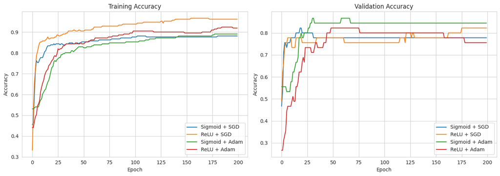

```python
fig, axes = plt.subplots(1, 2, figsize=(14, 5))

for name, vals in results.items():
    axes[0].plot(vals['history'].history['accuracy'], label=name)
    axes[1].plot(vals['history'].history['val_accuracy'], label=name)

axes[0].set_title('Training Accuracy')
axes[0].set_xlabel('Epoch')
axes[0].set_ylabel('Accuracy')
axes[0].legend()

axes[1].set_title('Validation Accuracy')
axes[1].set_xlabel('Epoch')
axes[1].set_ylabel('Accuracy')
axes[1].legend()

plt.tight_layout()
plt.show()
```

### 3.3 Best Model Evaluation

```
=== Best Keras Model - Test Set Report ===

               precision    recall  f1-score   support

   No Disease       0.72      0.86      0.78        21
Heart Disease       0.86      0.72      0.78        25

     accuracy                           0.78        46
    macro avg       0.79      0.79      0.78        46
 weighted avg       0.79      0.78      0.78        46
```

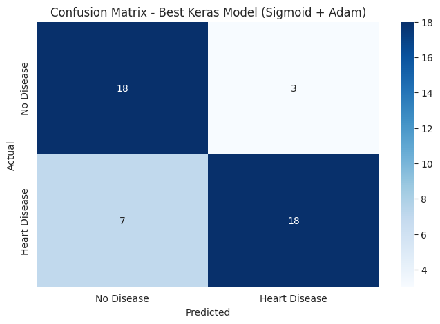

```python
# Retrain best model for detailed evaluation
tf.random.set_seed(42)
best_model = Sequential([
    Dense(8, activation='sigmoid', input_shape=(13,)),
    Dense(1, activation='sigmoid')
])
best_model.compile(optimizer=tf.keras.optimizers.Adam(learning_rate=0.001),
                   loss='binary_crossentropy', metrics=['accuracy'])

best_history = best_model.fit(X_train_scaled, y_train_np,
                              validation_data=(X_val_scaled, y_val_np),
                              epochs=200, batch_size=32, verbose=0)

# Predictions
y_test_pred_keras = (best_model.predict(X_test_scaled, verbose=0) >= 0.5).astype(int).flatten()

print("=== Best Keras Model - Test Set Report ===\n")
print(classification_report(y_test, y_test_pred_keras, target_names=['No Disease', 'Heart Disease']))

cm = confusion_matrix(y_test, y_test_pred_keras)
sns.heatmap(cm, annot=True, fmt='d', cmap='Blues',
            xticklabels=['No Disease', 'Heart Disease'],
            yticklabels=['No Disease', 'Heart Disease'])
plt.xlabel('Predicted')
plt.ylabel('Actual')
plt.title('Confusion Matrix - Best Keras Model (Sigmoid + Adam)')
plt.show()
```

## Part 4: Hyperparameter Analysis

### 4.1 Learning Rate Experiment

```python
learning_rates = [0.0001, 0.001, 0.01, 0.1]
lr_results = {}

for lr in learning_rates:
    tf.random.set_seed(42)
    model = Sequential([
        Dense(8, activation='sigmoid', input_shape=(13,)),
        Dense(1, activation='sigmoid')
    ])
    model.compile(optimizer=tf.keras.optimizers.Adam(learning_rate=lr),
                  loss='binary_crossentropy', metrics=['accuracy'])

    history = model.fit(X_train_scaled, y_train_np,
                        validation_data=(X_val_scaled, y_val_np),
                        epochs=200, batch_size=32, verbose=0)

    train_acc = model.evaluate(X_train_scaled, y_train_np, verbose=0)[1]
    val_acc = model.evaluate(X_val_scaled, y_val_np, verbose=0)[1]
    test_acc = model.evaluate(X_test_scaled, y_test_np, verbose=0)[1]

    lr_results[lr] = {'Train': train_acc, 'Val': val_acc, 'Test': test_acc, 'history': history}
    print(f"LR={lr:<8} → Train: {train_acc:.4f}  Val: {val_acc:.4f}  Test: {test_acc:.4f}")
```

```
LR=0.0001   → Train: 0.7346  Val: 0.8222  Test: 0.6087
LR=0.001    → Train: 0.8957  Val: 0.8000  Test: 0.7826
LR=0.01     → Train: 0.9621  Val: 0.8222  Test: 0.7609
LR=0.1      → Train: 1.0000  Val: 0.8444  Test: 0.7391
```

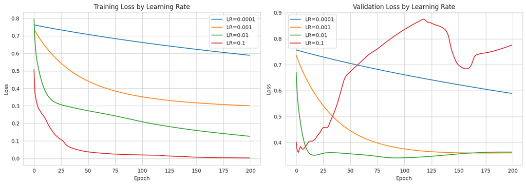

```python
fig, axes = plt.subplots(1, 2, figsize=(14, 5))

for lr, vals in lr_results.items():
    axes[0].plot(vals['history'].history['loss'], label=f'LR={lr}')
    axes[1].plot(vals['history'].history['val_loss'], label=f'LR={lr}')

axes[0].set_title('Training Loss by Learning Rate')
axes[0].set_xlabel('Epoch')
axes[0].set_ylabel('Loss')
axes[0].legend()

axes[1].set_title('Validation Loss by Learning Rate')
axes[1].set_xlabel('Epoch')
axes[1].set_ylabel('Loss')
axes[1].legend()

plt.tight_layout()
plt.show()
```

### 4.2 Architecture Experiment

```python
architectures = {
    '1 Layer (4)':    [4],
    '1 Layer (8)':    [8],
    '1 Layer (16)':   [16],
    '2 Layers (8,4)': [8, 4],
    '2 Layers (16,8)':[16, 8],
    '3 Layers (16,8,4)': [16, 8, 4],
}

arch_results = {}

for name, layers in architectures.items():
    tf.random.set_seed(42)
    model = Sequential()
    model.add(Dense(layers[0], activation='sigmoid', input_shape=(13,)))
    for neurons in layers[1:]:
        model.add(Dense(neurons, activation='sigmoid'))
    model.add(Dense(1, activation='sigmoid'))

    model.compile(optimizer=tf.keras.optimizers.Adam(learning_rate=0.001),
                  loss='binary_crossentropy', metrics=['accuracy'])

    history = model.fit(X_train_scaled, y_train_np,
                        validation_data=(X_val_scaled, y_val_np),
                        epochs=200, batch_size=32, verbose=0)

    train_acc = model.evaluate(X_train_scaled, y_train_np, verbose=0)[1]
    val_acc = model.evaluate(X_val_scaled, y_val_np, verbose=0)[1]
    test_acc = model.evaluate(X_test_scaled, y_test_np, verbose=0)[1]

    arch_results[name] = {'Train': train_acc, 'Val': val_acc, 'Test': test_acc}
    print(f"{name:<22} → Train: {train_acc:.4f}  Val: {val_acc:.4f}  Test: {test_acc:.4f}")
```

```
1 Layer (4)            → Train: 0.8720  Val: 0.8444  Test: 0.7609
1 Layer (8)            → Train: 0.8863  Val: 0.8000  Test: 0.7826
1 Layer (16)           → Train: 0.8863  Val: 0.8222  Test: 0.7826
2 Layers (8,4)         → Train: 0.8815  Val: 0.7333  Test: 0.7826
2 Layers (16,8)        → Train: 0.9005  Val: 0.7556  Test: 0.7174
3 Layers (16,8,4)      → Train: 0.9005  Val: 0.7333  Test: 0.7174
```

```
=== Learning Rate Results ===

              Train       Val      Test
LR=0.0001  0.734597  0.822222  0.608696
LR=0.001   0.895735  0.800000  0.782609
LR=0.01    0.962085  0.822222  0.760870
LR=0.1     1.000000  0.844444  0.739130


=== Architecture Results ===

                      Train       Val      Test
1 Layer (4)        0.872038  0.844444  0.760870
1 Layer (8)        0.886256  0.800000  0.782609
1 Layer (16)       0.886256  0.822222  0.782609
2 Layers (8,4)     0.881517  0.733333  0.782609
2 Layers (16,8)    0.900474  0.755556  0.717391
3 Layers (16,8,4)  0.900474  0.733333  0.717391
```

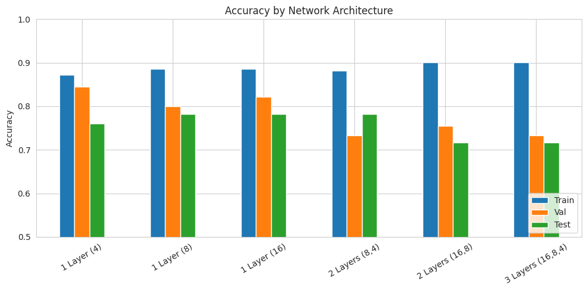

```python
# Combined results table
print("=== Learning Rate Results ===\n")
lr_df = pd.DataFrame({f'LR={k}': {m: v for m, v in vals.items() if m != 'history'}
                       for k, vals in lr_results.items()}).T
print(lr_df.to_string())

print("\n\n=== Architecture Results ===\n")
arch_df = pd.DataFrame(arch_results).T
print(arch_df.to_string())

# Bar chart comparing architectures
fig, ax = plt.subplots(figsize=(10, 5))
arch_df.plot(kind='bar', ax=ax, rot=30)
ax.set_title('Accuracy by Network Architecture')
ax.set_ylabel('Accuracy')
ax.set_ylim(0.5, 1.0)
ax.legend(loc='lower right')
plt.tight_layout()
plt.show()
```

## Part 5: Written Analysis & Reflection

In this case study, I built a neural network from scratch using NumPy to predict heart disease, and then recreated the same using Keras. The scratch implementation had 13 input features, 8 hidden neurons with sigmoid activation, and 1 output neuron. My first attempt with learning rate 0.01 and 200 epochs did not work at all — the model was just guessing randomly with 54% accuracy. After increasing the learning rate to 0.1 and training for 1000 epochs, the accuracy improved to 76% on test data. In Keras, I tried different activations and optimizers and found that Sigmoid with Adam optimizer gave the best test accuracy of 78.3%.

One ethical concern I noticed is the gender imbalance in the dataset. There are many more male patients than female patients. Since this is a medical dataset, this is a serious issue. Heart disease in women is already underdiagnosed in real life, and if our model has mostly learned from male patient data, it may not predict correctly for female patients. Wrong predictions in healthcare can have very dangerous consequences.

To reduce this risk, one simple step would be to check the model accuracy separately for male and female patients. If there is a big gap, we can try collecting more female patient data, or use techniques like oversampling to balance the gender representation in our training set.

The biggest learning from this case study is that tuning hyperparameters matters a lot. A wrong learning rate can make the model completely useless. I also learned that deeper and bigger networks are not always better — on small datasets like this one (only 302 samples), simple models actually perform better because complex models tend to memorize the training data instead of learning general patterns. Building the network from scratch really helped me understand what is happening inside forward propagation and backpropagation, which Keras hides from us.